# Finding lineage-defining variants in Michigan nursing home VREfm

Detection of multi-strain colonization using lineage-defining variants curated from sequenced clones will be highly robust to sequencing errors and false-positive variant calls due to the strict criteria that known sets of variants at specific positions be present to confirm the presence of a strain.

Ali has generated gubbins-filtered alignment and tree in: /nfs/esnitkin/Project_VRE_metagenomics_analysis/Sequence_data/output_files/2021_04_09_VREfm_variant_calling/2021_04_12_15_54_54_core_results/gubbins/

```r
library(ggplot2)
```

```r
# file = "../figures/VREfm_iqtree_ML.pdf"
# pdf(file)
par(mar = c(1, 1, 1, 1))
plot(phylo, cex = .25)

# dev.off()

vrefm_st = subtrees(phylo)

tree_vars = lapply(vrefm_st, FUN = function(l){

  temp_mat = var_pos2[l$tip.label,]

  shared = apply(temp_mat, 2 , FUN = function(x){length(unique(x)) == 1})

  uniq_snv = apply(temp_mat[,names(which(shared))] , 2, FUN = function(x){unique(x)})

  uniq_snv
})

tree_nodes = 1:length(vrefm_st) # skip first subtree because there are no lineage-defining variants for the overall tree

tree_pairs = list()

for (s in tree_nodes){print(s)

  test_samples = vrefm_st[[s]]$tip.label

  test_tree = tree_vars[[s]]

  test_tree_uniq_var = sapply(names(test_tree), FUN = function(r){

  test_snv = var_pos2[test_samples, r]

  if (unique(test_snv) != test_tree[r]){stop} # extra check

  sum(unique(test_snv) %in% names(table(var_pos2[!rownames(var_pos2) %in% test_samples,r]))) == 0

  })

  if (length(test_tree_uniq_var) == 0){tree_pairs[[as.character(s)]] = NULL}else{
  tree_pairs[[as.character(s)]] = names(which(test_tree_uniq_var))}
}

shared_mat = matrix(NA, nrow = nrow(var_pos2), ncol = length(unique(unlist(tree_pairs[-1]))), dimnames = list(phylo$tip.label, as.character(sort(as.numeric(unique(unlist(tree_pairs[-1])))))))

# remove the first subtree since it's the whole tree!
for (p in names(which(unlist(lapply(tree_pairs[-1], length)) > 0))){print(p)

  isolates = vrefm_st[[as.numeric(p)]]$tip.label
  snv_pos = tree_pairs[[p]]
  snv = apply(var_pos2[isolates, snv_pos, drop = F], 2, unique)

  shared_mat[isolates, snv_pos] = matrix(rep(snv, each =  length(isolates)), byrow = F, ncol = length(snv_pos))
}


shared_mat2 = apply(shared_mat, 1:2, FUN = function(m){
    if (is.na(m)){n = 0}
    if (m %in% "A"){n = 1}
    if (m %in% "T"){n = 2}
    if (m %in% "C"){n = 3}
    if (m %in% "G"){n = 4}
  n
})
```

[output not shown]

```r
pheatmap(shared_mat2, cluster_rows = F, cluster_cols = T, show_rownames = T, show_colnames = T, fontsize_col = .5, fontsize_row = .5, filename = "../figures/random.pdf")

plot(phylo, no.margin = FALSE, show.tip.label = FALSE, use.edge.length = T)
tiplabels(pch = 16, col = shared_mat2[,"904043"], cex = .5)

# Combine tree with heatmap
phy <- ggtree(phylo)

shared_df = as.data.frame(shared_mat, stringsAsFactors = F)

cols=c("steelblue", "firebrick", "darkgreen", "orange", "white")
names(cols) = c("A", "T", "C", "G")

# pdf("../figures/ggrandom.pdf")
#
# gheatmap(phy, shared_df, offset=0, width=1, font.size=.5, colnames = F, legend_title="Lineage-defining\nmakrer") + scale_fill_manual(values=cols)

# dev.off()
```

[output not shown]

Evan’s feedback: April-30-2021 - A few thoughts: 1. Can you make a histogram of number of LDVs per subtree? Just curious if there are typically more than one or two. 2. Do you think there is a way to visualize which subtrees have LDVs versus which do not? 3. Following on the previous point, I wonder if there is some way to get a sense of the resolution provided by LDVs. A few possibilities: i) for each isolate determine the smallest subtree that it belongs to that has at least one LDV (i.e. how small are the groups we are creating) and ii) for each isolates smallest LDV-defined subtree, determine the maximum genetic distance to another isolate in the subtree (i.e. what is our genetic distance resolution using LDVs)?

May-1-2021 - Oh - one other thing, can we also see what fraction of tips have variants that are unique to them?

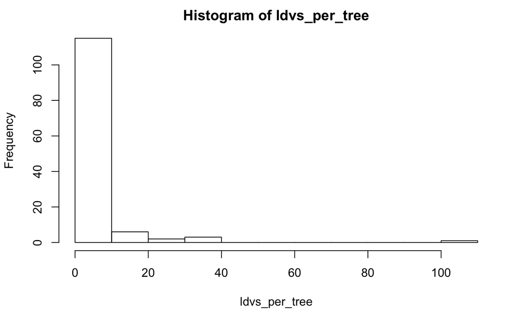